# WILD 591 – Spatial Population Modeling

Lesson 11: Distance Sampling

Mahdieh Tourani

2026-10-16

# Where we’re going

## Roadmap for today

1. Ecological state as point pattern summaries
2. Distance Sampling Framework
3. Hiararchical Distance Sampling

# 1.1 Point Processes

## Point patterns

> Point patterns are the outcome of stochastic processes known as point processes, and statistical models describing them are called point process models.
- PPMs treat both the number and the locations of discrete points as random quantities governed by an underlying, continuous intensity field.
- The intensity is the expected number of points (e.g., animals or plants) per unit area in some study area and is the modeled parameter.

## Point pattern and state variables

Distribution and abundance are summaries of spatial point patterns, i.e., aggregation of a point pattern over some area.

## Simulated relationships

- abundance N: the number of points falling into each “site” (i.e., cell) if there is no point in a cell, abundance is zero; if there is one point, abundance is one; and so on.
- presence/absence (z): either no point in a cell (absence or non-occurrence) or there is at least one point in the cell (i.e., presence or occurrence).
- abundance is a first step of aggregating an underlying point pattern within some spatial discretization scheme, and occurrence is a second step in this aggregation over the spatial units.
- occurrence is a simple information-poor summary of abundance or “the poor man’s abundance,” where we only keep track of two abundance classes.

# 1.2 Population size

## Abundance

> Abundance is the number of individuals in a population at a specific time and location

> Density is abundance per unit area

$$\hat{D} = \frac{\hat{N}}{A}$$
$A$: sampled area

# 2.1 Distance Sampling Framework

## Conventional Distance Sampling

$$\hat{D} = \frac{\sum_{s=1}^{S}n_s }{\sum_{s=1}^{S}a_s }$$

$n_s$: count at each sample unit $s$ $a_s$: surface of each sample unit $s$

> Density is the number of counted animals divided by the surface on the transets

$$\hat{N} = \frac{\sum_{s=1}^{S}n_s }{\alpha}$$
$\alpha$: Proportion of study area sampled

## Survey Geometry

- Line Transect: Length $L$, strip half-width $W$, covered area of one transect $a = 2 w L$.

$$\hat{D} = \frac{\sum_{s=1}^{S}n_s }{\sum_{s=1}^{S}L_s \times 2 \times W }$$

- Point Transect: radius $W$, covered area $a = \pi W^2$.

$$\hat{D} = \frac{\sum_{s=1}^{S}n_s }{\sum_{s=1}^{S} \pi \times W^2 }$$

- Detection probability is assumed to be perfect.

## Imperfect detection

- **Detection Function** $g(x)$:
  - Probability of detecting an animal at perpendicular distance $x \in [0, W]$.
- **Core CDS Assumptions**:
  1. Animals on the line/point are detected with certainty: $g(0) = 1$.
  2. Animals are detected at their initial location (no movement prior to detection).
  3. Distance $x$ is measured without error.
  4. Detections are independent events.

Where do you think the detection probability shoud be in the previous equations?

## With p<1

$$\hat{N} = \frac{n}{\hat{p}}$$

$p$: detection probability

$$\hat{D} = \frac{\sum_{s=1}^{S}n_s }{\hat{p}\sum_{s=1}^{S}a_s }$$

## Example survey

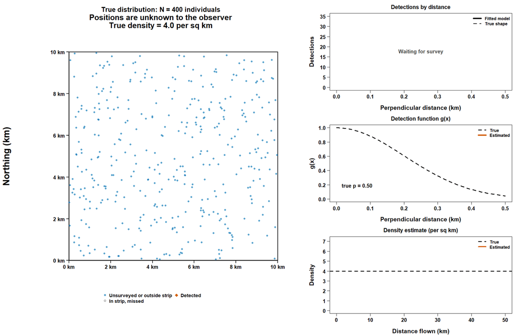

## Popularity

- Distance sampling methods are performed with one sample occasion (visit) and no individual identification.
- Distance sampling models provide reliable estimates of density and abundance if DS assumptions are met.

## Activity

**Format**: Form 3 groups

**Materials**: 1 set of histograms showing counts of animals against distance and 6 field stories per group

**Your task**: Match each histogram to one of the field stories.

# 2.2 Hierarchical Distance Sampling

## Model structure: part 1

- Observation Submodel:

$$y_{ij} \sim Bernoulli(p_{ij} \times z_i)$$

$$\text{h}_{ij}=\exp(p_0)\exp\!\big(-d_{ij}^2/(2\sigma^2)\big),\qquad p_{ij}=1-\exp(-\text{h}_{ij})$$

## Model structure: part 2

- Ecological Submodel:

$$u_i \sim Uniform (S)$$

$u_i$: spatial locations of individuals  
$S$: the state-space of the point process  
$N$: the number of points in $S$, i.e., the population size exposed to sampling.

$${D} = \frac{N}{A(S)}$$
$$z_i\sim\text{Bernoulli}(\psi),\quad i=1,\dots,M;\qquad N=\sum_{i=1}^{M}z_i$$

## Data augmentation

> Augment dataset with all-zero detection histories up to superpopulation $M$.

Latent indicator $z_i \sim \text{Bernoulli}(\psi)$.
$$z_i\sim\text{Bernoulli}(\psi),\quad i=1,\dots,M;\qquad N=\sum_{i=1}^{M}z_i,\quad \psi\sim\text{Uniform}(0,1)$$